# Predicting 2022 CFB Games

# What is this?

This page displays predictions for games in the 2022 CFB season. These predictions come from a model built on historical college football play by play and game data in order to simulate upcoming games. All data is from collegefootballdata.com.

# 1 Week 2 Predictions

This table displays the results of simulating week 2 of the 2022 CFB season 1000 times. These simulations are run one week in advance, using information available in the lead up to week 2. For the first week of the season, team ratings are based solely on information from previous seasons.

**Quality** is the (harmonic) mean of the two team’s overall rating, with 100 indicating a game between highly rated opponents. **Pr(HomeWin)** is the percentage of times that the home team won the game across every simulation.

| Season | Week | Quality | Home | Away | Pr(HomeWin) | Prediction | Result | Correct | correct |
| --- | --- | --- | --- | --- | --- | --- | --- | --- | --- |
| 2022 | 2 | 89 | Texas | Alabama | 0.197 | Alabama by 14 |  |  |  |
| 2022 | 2 | 76 | BYU | Baylor | 0.488 | Baylor by 1 |  |  |  |
| 2022 | 2 | 74 | Florida | Kentucky | 0.535 | Florida by 1 |  |  |  |
| 2022 | 2 | 73 | Pittsburgh | Tennessee | 0.647 | Pittsburgh by 6 |  |  |  |
| 2022 | 2 | 72 | Arkansas | South Carolina | 0.768 | Arkansas by 11 |  |  |  |
| 2022 | 2 | 72 | Oklahoma State | Arizona State | 0.806 | Oklahoma State by 14 |  |  |  |
| 2022 | 2 | 70 | Texas A&M | Appalachian State | 0.840 | Texas A&M by 16 |  |  |  |
| 2022 | 2 | 70 | Wisconsin | Washington State | 0.758 | Wisconsin by 11 |  |  |  |
| 2022 | 2 | 70 | Iowa | Iowa State | 0.618 | Iowa by 5 |  |  |  |
| 2022 | 2 | 67 | Notre Dame | Marshall | 0.853 | Notre Dame by 18 |  |  |  |

[output cut: 72 more lines]

# 2 Results Through Week 1

How has the model performed so far in 2022?

## 2.1 Assessment

The model predicts the probability that the home team will win and their expected margin of victory (or defeat). I assess the model’s performance by assessing the accuracy of its predictions (win/loss), the logloss of its probabilities, and the mean absolute error of the margin.

| Season | Week | N | Outcome Accuracy | Outcome LogLoss | Margin MAE |
| --- | --- | --- | --- | --- | --- |
| 2022 | 1 | 94 | 0.82 | 0.37 | 15.0 |
| Season Average: |  |  | 0.82 | 0.37 | 15.0 |

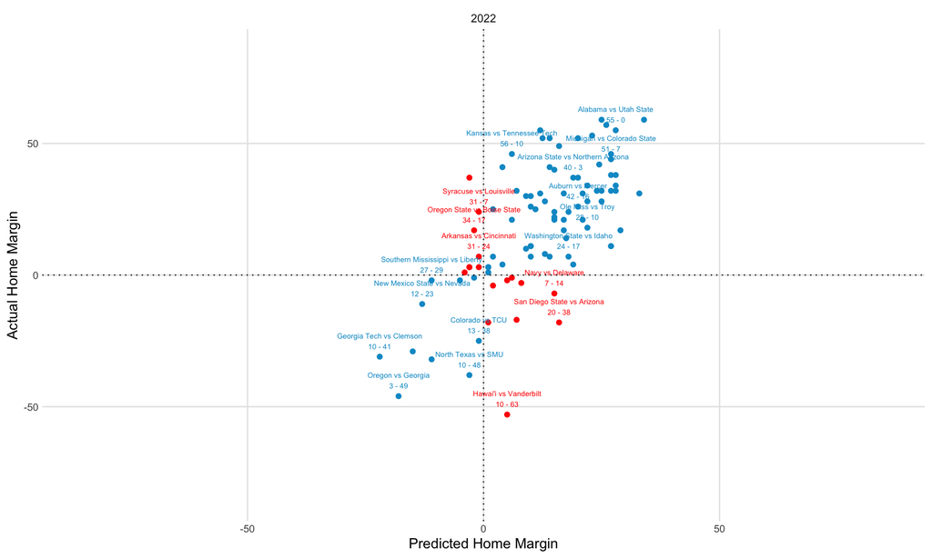

## 2.2 Results

The following table shows the results of games played in previous weeks next to the model’s predictions.

| Season | Week | Quality | Home | Away | Pr(HomeWin) | Prediction | Result | Correct | correct |
| --- | --- | --- | --- | --- | --- | --- | --- | --- | --- |
| 2022 | 1 | 100 | Oregon | Georgia | 0.179 | Georgia by 18 | Georgia by 46 | Yes | 1 |
| 2022 | 1 | 95 | Ohio State | Notre Dame | 0.724 | Ohio State by 10 | Ohio State by 11 | Yes | 1 |
| 2022 | 1 | 81 | Alabama | Utah State | 0.947 | Alabama by 28 | Alabama by 55 | Yes | 1 |
| 2022 | 1 | 81 | Arkansas | Cincinnati | 0.498 | Cincinnati by 1 | Arkansas by 7 | No | 0 |
| 2022 | 1 | 74 | Florida | Utah | 0.452 | Utah by 3 | Florida by 3 | No | 0 |
| 2022 | 1 | 71 | Purdue | Penn State | 0.566 | Purdue by 2 | Penn State by 4 | No | 0 |
| 2022 | 1 | 68 | Florida State | LSU | 0.422 | LSU by 4 | Florida State by 1 | No | 0 |
| 2022 | 1 | 68 | Georgia Tech | Clemson | 0.112 | Clemson by 22 | Clemson by 31 | Yes | 1 |
| 2022 | 1 | 68 | Oklahoma State | Central Michigan | 0.853 | Oklahoma State by 17.5 | Oklahoma State by 14 | Yes | 1 |
| 2022 | 1 | 65 | Pittsburgh | West Virginia | 0.742 | Pittsburgh by 10 | Pittsburgh by 7 | Yes | 1 |

[output cut: 85 more lines]

# 3 Predicting the Rest of the Season

This table displays the results of simulating the rest of the 2022 season 1000 times. These simulations are run weeks in advance, where the remainder of the season is simulated using only the information as of week 1.

For example, we simulate the entire season before any games are played by simulating week two based on the (simulated) results of week one, then simulating week three based on the (simulated) results from week two. As a result, predictions for future weeks tend to be less accurate than predictions made one week in advance and are likely to change as we get closer to the actual game.

| Season | Week | Quality | Home | Away | Pr(HomeWin) | Prediction | Result | Correct | correct |
| --- | --- | --- | --- | --- | --- | --- | --- | --- | --- |
| 2022 | 2 | 89 | Texas | Alabama | 0.197 | Alabama by 14 |  |  |  |
| 2022 | 2 | 76 | BYU | Baylor | 0.488 | Baylor by 1 |  |  |  |
| 2022 | 2 | 74 | Florida | Kentucky | 0.535 | Florida by 1 |  |  |  |
| 2022 | 2 | 73 | Pittsburgh | Tennessee | 0.647 | Pittsburgh by 6 |  |  |  |
| 2022 | 2 | 72 | Arkansas | South Carolina | 0.768 | Arkansas by 11 |  |  |  |
| 2022 | 2 | 72 | Oklahoma State | Arizona State | 0.806 | Oklahoma State by 14 |  |  |  |
| 2022 | 2 | 70 | Texas A&M | Appalachian State | 0.840 | Texas A&M by 16 |  |  |  |
| 2022 | 2 | 70 | Wisconsin | Washington State | 0.758 | Wisconsin by 11 |  |  |  |
| 2022 | 2 | 70 | Iowa | Iowa State | 0.618 | Iowa by 5 |  |  |  |
| 2022 | 2 | 67 | Notre Dame | Marshall | 0.853 | Notre Dame by 18 |  |  |  |

[output cut: 742 more lines]